# Figure 4. Analyses of Growth rate experiment using Softbugs isolated from the environment

## Assay 3: Combined

```r
assay3 <- bind_rows(assay1, assay2)
assay3 <- assay3 %>%
  select(Ps.genotype, Invader, Inv.strain, Ps.strain, Plate, Invasion.score) %>%
  arrange(Ps.genotype, Invader, Inv.strain, Ps.strain, Plate)
assay3 <- assay3 %>% filter(!is.na(Invasion.score))
assay3$Ps.genotype <- as.factor(assay3$Ps.genotype)
assay3$Ps.genotype <- fct_relevel(assay3$Ps.genotype, "Control", "Ps1", "Ps2")
assay3$Inv.strain <- as_factor(as.character(assay3$Inv.strain))
assay3$Inv.strain_shape <- if_else(assay3$Inv.strain == "18", "2", "16")
assay3$Invader <- as_factor(assay3$Invader) %>% fct_relevel("Soft_bug", "Streptomyces")
assay3$Ps.strain <- as_factor(assay3$Ps.strain)
assay3$Plate <- as_factor(as.character(assay3$Plate))
tbl_df(assay3) # 975 rows and 7 cols
```

```
## # A tibble: 975 x 7
##    Ps.genotype Invader Inv.strain Ps.strain Plate Invasion.score
##    <fct>       <fct>   <fct>      <fct>     <fct>          <dbl>
##  1 Control     Soft_b… 11         Control   1              1.24
##  2 Control     Soft_b… 11         Control   2              0.495
##  3 Control     Soft_b… 11         Control   3              0
##  4 Control     Soft_b… 12         Control   1              0.89
##  5 Control     Soft_b… 12         Control   2              0.675
##  6 Control     Soft_b… 12         Control   3              0.89
##  7 Control     Soft_b… 13         Control   1              1.38
##  8 Control     Soft_b… 13         Control   2              0.755
##  9 Control     Soft_b… 13         Control   3              1.38
## 10 Control     Soft_b… 14         Control   1              0.863
## # … with 965 more rows, and 1 more variable: Inv.strain_shape <chr>
```

Create crosstabs to see experimental design

```r
assay4 <- assay3 %>% filter(Ps.strain != "Control")
assay4$Ps.strain <- droplevels(assay4$Ps.strain)
xtabs(~ Inv.strain + Ps.strain + Plate, assay4)
```

```
## , , Plate = 1
##
##           Ps.strain
## Inv.strain B D F M Ø T A E G J K L N P Q R S
##         11 1 1 1 1 1 1 1 1 1 1 1 1 1 0 1 1 1
##         12 1 1 1 1 1 1 1 1 1 1 1 1 1 0 1 1 1
##         13 1 1 1 1 1 1 1 1 1 1 1 1 1 0 1 1 1
##         14 1 1 1 1 1 1 1 1 1 1 1 1 1 0 1 1 1
##         15 1 1 1 1 1 1 1 1 1 1 1 1 1 0 1 1 1
##         16 1 1 1 1 1 1 1 1 1 1 1 1 1 0 1 1 1
##         17 1 1 1 1 1 1 1 1 1 1 1 1 1 0 1 1 1
##         18 1 1 1 1 1 1 1 1 1 1 1 1 1 0 1 1 1
##         19 1 1 1 1 1 1 1 1 1 1 1 1 1 0 1 1 1
##         20 1 1 1 1 1 1 1 1 1 1 1 1 1 0 1 1 1
##         1  1 1 1 1 1 1 1 1 1 1 1 1 1 1 1 1 0
```

[output cut: 59 more lines]

```r
rm(assay4)

assay5 <- assay3 %>% filter(Ps.strain == "Control")
assay5$Ps.strain <- droplevels(assay5$Ps.strain)
xtabs(~ Inv.strain + Ps.strain + Plate, assay5)
```

```
## , , Plate = 1
##
##           Ps.strain
## Inv.strain Control
##         11       1
##         12       1
##         13       1
##         14       1
##         15       1
##         16       1
##         17       1
##         18       1
##         19       1
##         20       1
##         1        1
```

[output cut: 59 more lines]

```r
rm(assay5)
```

sample sizes

```r
assay1 %>% count(Invader, Ps.genotype)
```

```
## # A tibble: 3 x 3
##   Invader      Ps.genotype     n
##   <chr>        <chr>       <int>
## 1 Streptomyces Control        30
## 2 Streptomyces Ps1           170
## 3 Streptomyces Ps2           292
```

```r
assay2 %>% count(Invader, Ps.genotype)
```

```
## # A tibble: 3 x 3
##   Invader  Ps.genotype     n
##   <chr>    <chr>       <int>
## 1 Soft_bug Control        30
## 2 Soft_bug Ps1           149
## 3 Soft_bug Ps2           304
```

```r
assay3 %>% count(Invader, Ps.genotype, Plate)
```

```
## # A tibble: 18 x 4
##    Invader      Ps.genotype Plate     n
##    <fct>        <fct>       <fct> <int>
##  1 Soft_bug     Control     1        10
##  2 Soft_bug     Control     2        10
##  3 Soft_bug     Control     3        10
##  4 Soft_bug     Ps1         1        60
##  5 Soft_bug     Ps1         2        60
##  6 Soft_bug     Ps1         3        29
##  7 Soft_bug     Ps2         1       100
##  8 Soft_bug     Ps2         2       100
##  9 Soft_bug     Ps2         3       104
## 10 Streptomyces Control     1        10
## 11 Streptomyces Control     2        10
## 12 Streptomyces Control     3        10
## 13 Streptomyces Ps1         1        60
## 14 Streptomyces Ps1         2        60
## 15 Streptomyces Ps1         3        50
## 16 Streptomyces Ps2         1       100
## 17 Streptomyces Ps2         2        96
## 18 Streptomyces Ps2         3        96
```

To read these tables:

1. We infused the media with antibiotics from 17 *Pseudonocardia* lines that had been collected from different ant colonies (A-S), plus a non-infused control media. There are potentially genetic differences among these vertically transmitted lineages, so we call them: Ps.strain
2. We measured growth rates of 10 strains of *Streptomyces* (1-10) and 10 strains of Softbugs (11-20). These are invading strains so we call them: Inv.strain.
3. Each of the (17 * 20 =) 340 combinations of Ps.strain and Inv.strain was repeated 3 times for a total sample size of (340 * 3 =) 1020 treatment inoculations and 60 control inoculations, but some colonies could not be scored due to difficulties in reading colony area, leaving us with (170 + 292 =) 462 *Streptomyces* inoculations and (149 + 304 =) 453 Softbugs inoculations. 462 + 453 = 915 total treatment inoculations + (20 * 3 =) 60 control inoculations = 975 total inoculations.
4. Thus, the experiment is fully crossed but somewhat imbalanced at the end.
5. (510 - 462 =) 48 Streptomyces inoculations and (510 - 453 =) 57 Softbug inoculations could not be scored. Note that we did score cases where there was no growth.

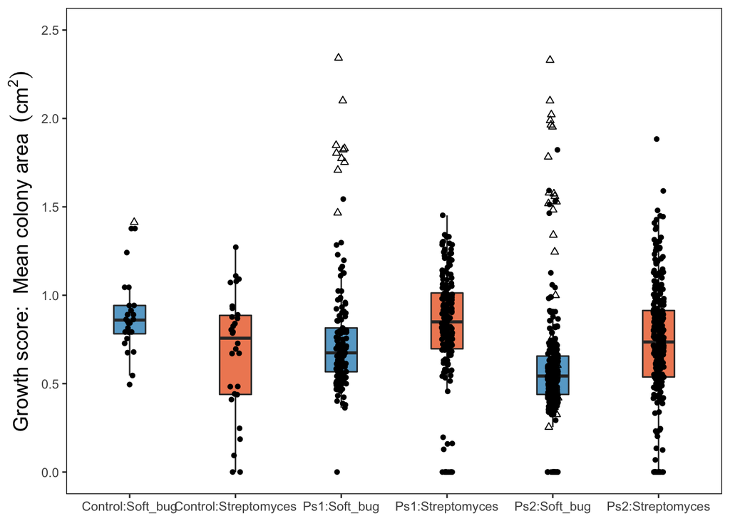

```r
colorvec <- brewer.pal(3, "RdBu")
colorvec <- c(colorvec[3], colorvec[1], colorvec[2])

p <- ggplot(assay3, aes(x = Ps.genotype:Invader, y = Invasion.score))

# truncated y-axis version for publication
(q <- p + ylim(0, 2.5)
  + geom_boxplot(size = .5, outlier.shape = NA, width = 0.3, aes(fill = assay3$Invader))
  + geom_jitter(width = 0.05, cex = 1.5, aes(shape = assay3$Inv.strain_shape))
  + scale_shape_manual(values = c(16, 2))
  + labs(y = expression("Growth score:  Mean colony area " ~ (cm^{
    2
  })))
  # + scale_fill_brewer(type = "qual", palette = "Set3") # alternative color set
  + scale_fill_manual(values = colorvec)
  + theme(
    axis.title.y = element_text(size = 14),
    axis.title.x = element_blank(),
    legend.position = "none",
    panel.background = element_rect(fill = "white"),
    # panel.grid.major.y = element_line(colour = "grey", size = 0.5),
    # panel.grid.minor.y = element_line(colour = "grey", size = 0.1),
    panel.border = element_rect(colour = "black", fill = NA)
  )
)
```

```r
# the published figure was edited outside of R to add the grey panel and x-axis labelling.
```

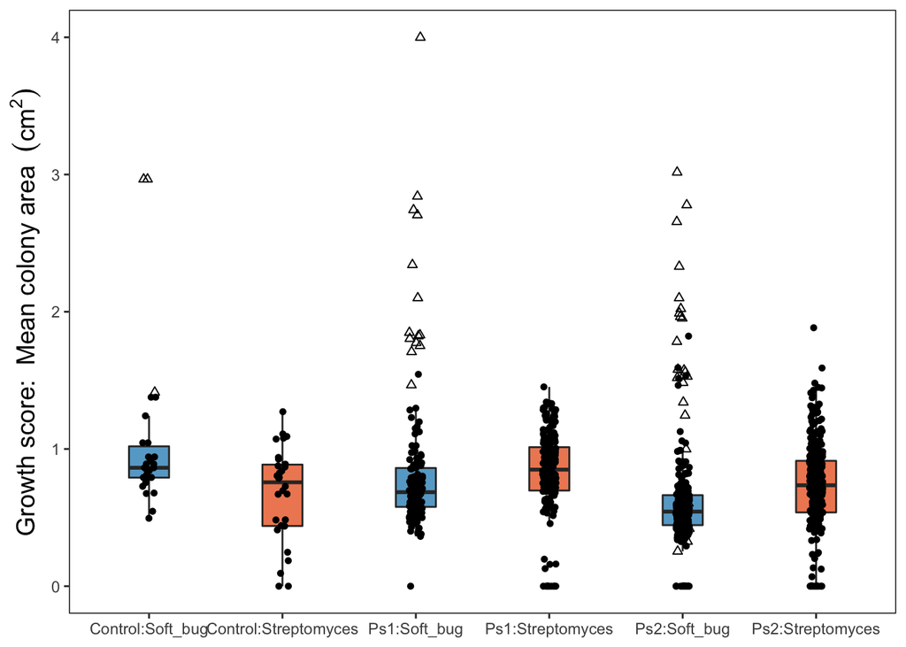

```r
# non-truncated y-axis version. Analysis uses the whole dataset
q + ylim(0, 4)
```

To read these boxplots:

1. The y-axis is the final area (cm<sup>2</sup>) of the colony inoculated onto the plate (the notional ‘invader’)
2. On control media (left 2 columns), Soft-bug colonies (blue) grow bigger (more quickly) than do *Streptomyces* colonies (orange).
3. However, on *Pseudonocardia*-infused media (Ps1, Ps2), *Streptomyces* colonies (orange) grow more quickly than do soft-bug colonies (blue).
4. The 17 *Pseudonocardia* colonies (Ps.strain) used to infuse the media can be usefully divided into two 16S genotypes (Ps1 n = 6, Ps2 n = 11). Growth rates of *Streptomyces* and softbugs appear lower on the Ps2 infusions (i.e. Ps2 appears to be a more effective inhibitor in general).
5. There are fewer Control datapoints because this represents only one kind of media, whereas the *Pseudonocardia* (Ps1 and Ps2) treatment represents 17 Ps lineages.
6. The empty triangles are all from Softbug strain 18, clearly demonstrating the existence of correlated residuals in the Inv.strain variable.

This dataset is used to choose strains for the pairwise competition experiment (Fig 6)

```r
(assay4.1 <- assay3 %>% group_by(Ps.genotype, Invader) %>% summarise(median.Invasion.score = round(median(Invasion.score), 2)))

assay4.2 <- assay3 %>%
  group_by(Ps.genotype, Invader, Inv.strain) %>%
  summarise(median.Invasion.score = round(median(Invasion.score), 2))

assay4.2 <- assay4.2 %>% arrange(Ps.genotype, Invader, median.Invasion.score)

assay4.3 <- assay3 %>%
  group_by(Ps.genotype, Ps.strain, Invader, Inv.strain) %>%
  summarise(median.Invasion.score = round(median(Invasion.score), 2))

# write.table(assay4.1, file = "assay4.1.tsv", quote = FALSE, sep = "\t") # use this to choose summary pairs for the competition experiment
# write.table(assay4.2, file = "assay4.2.tsv", quote = FALSE, sep = "\t") # use this to choose summary pairs for the competition experiment
# write.table(assay4.3, file = "assay4.3.tsv", quote = FALSE, sep = "\t") # use this to choose summary pairs for the competition experiment

rm(assay4.1, assay4.2, assay4.3)
```

## Start of analysis.

There are two potential random factors:

1. *Pseudonocardia* strains: `Ps.strain` (17 levels: A-S)
2. Invader strains: `Inv.strain` (20 levels: labeled 1-20). 1-10 are *Streptomyces* strains, 11-20 are Softbug strains

There are 3 Plate replicates for each combination of Ps.strain and Inv.strain, and each of the 20 Inv.strains is tested against each of the 17 Ps.strains. Some complexity: not all inoculations were scorable, so were omitted. This is a fully crossed but somewhat imbalanced experiment

There are 2 fixed factors:

1. Pseudonocardia genotype: `Ps.genotype` (Ps1, Ps2).
2. Invader type: `Invader` (softbugs, *Streptomyces*)

Finally, the response variable is:

1. Mean colony area (cm<sup>2</sup>): `Invasion.score`

Construct a full model and test for an interaction effect of medium (Ps.genotype) and Invader (*Streptomyces* and Softbugs) and also test for correlated residuals in each of the potential random factors

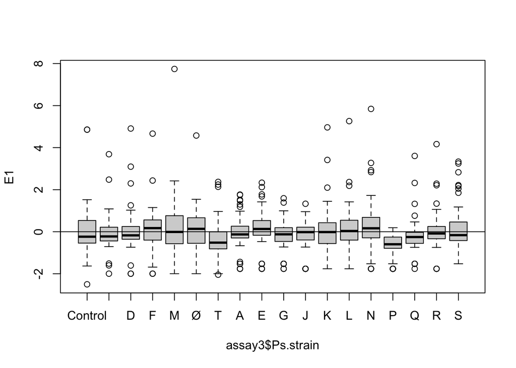

```r
M1 <- lm(Invasion.score ~ Invader * Ps.genotype, data = assay3)
E1 <- rstandard(M1)
plot(E1 ~ assay3$Ps.strain)
abline(0, 0) # T,P,Q strains either mostly above or below 0, demonstrating correlated residuals for some strains
```

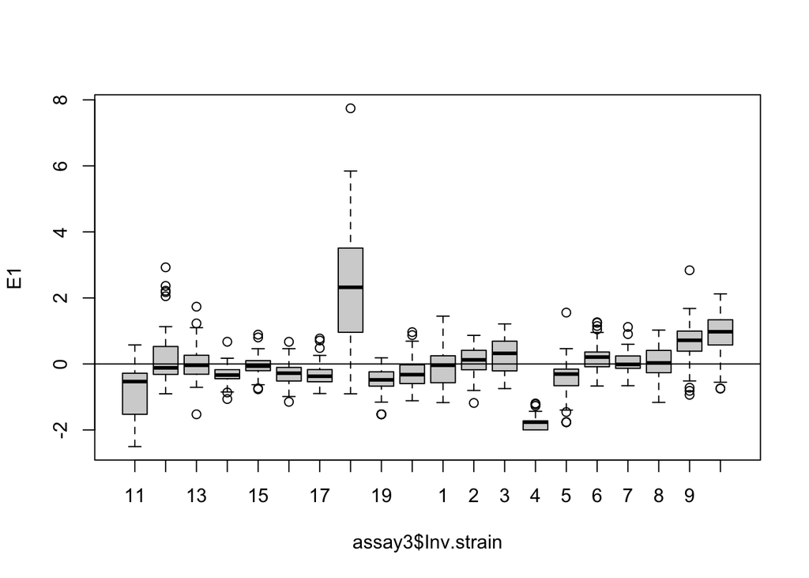

```r
plot(E1 ~ assay3$Inv.strain)
abline(0, 0) # 11,14,16,17,18,19,20,4,5,9,10 either mostly above or below 0, demonstrating correlated residuals for some strains. recall that 11-20 are softbugs and 1-10 are _Streptomyces_
```

```r
rm(M1)
rm(E1)
```

Thus, we use a model with random factors. In particular, note that Softbug strain 18 has a high growth rate, which we saw in the boxplot (empty triangle points)

```r
# with interaction effect
M1 <- lmer(Invasion.score ~ Invader * Ps.genotype + (1 | Ps.strain / Plate) + (1 | Inv.strain), data = assay3, REML = FALSE)
# without interaction effect
M2 <- lmer(Invasion.score ~ Invader + Ps.genotype + (1 | Ps.strain / Plate) + (1 | Inv.strain), data = assay3, REML = FALSE)

anova(M1, M2) # highly significant interaction effect:  p = 1.102e-10
```

```
## Data: assay3
## Models:
## M2: Invasion.score ~ Invader + Ps.genotype + (1 | Ps.strain/Plate) +
## M2:     (1 | Inv.strain)
## M1: Invasion.score ~ Invader * Ps.genotype + (1 | Ps.strain/Plate) +
## M1:     (1 | Inv.strain)
##    npar    AIC    BIC  logLik deviance  Chisq Df Pr(>Chisq)
## M2    8 305.25 344.31 -144.62   289.25
## M1   10 263.39 312.22 -121.70   243.39 45.858  2  1.102e-10 ***
## ---
## Signif. codes:  0 '***' 0.001 '**' 0.01 '*' 0.05 '.' 0.1 ' ' 1
```

```r
AIC(M1, M2) # AIC difference >> 2, and the model with the interaction effect has a much lower AIC:  263.39
```

```
##    df      AIC
## M1 10 263.3918
## M2  8 305.2498
```

Estimate parameter values

```r
M3 <- lmer(Invasion.score ~ Invader * Ps.genotype + (1 | Ps.strain / Plate) + (1 | Inv.strain), data = assay3, REML = TRUE)
summary(M3)
```

```
## Linear mixed model fit by REML ['lmerMod']
## Formula: Invasion.score ~ Invader * Ps.genotype + (1 | Ps.strain/Plate) +
##     (1 | Inv.strain)
##    Data: assay3
##
## REML criterion at convergence: 264
##
## Scaled residuals:
##     Min      1Q  Median      3Q     Max
## -4.6401 -0.4458 -0.0010  0.4204  8.1428
##
## Random effects:
##  Groups          Name        Variance Std.Dev.
##  Plate:Ps.strain (Intercept) 0.005484 0.07406
##  Inv.strain      (Intercept) 0.104897 0.32388
##  Ps.strain       (Intercept) 0.007559 0.08694
##  Residual                    0.064363 0.25370
## Number of obs: 975, groups:  Plate:Ps.strain, 53; Inv.strain, 20; Ps.strain, 18
##
## Fixed effects:
##                                    Estimate Std. Error t value
## (Intercept)                         1.00853    0.14840   6.796
## InvaderStreptomyces                -0.35117    0.15897  -2.209
## Ps.genotypePs1                     -0.16419    0.11653  -1.409
## Ps.genotypePs2                     -0.39268    0.11227  -3.498
## InvaderStreptomyces:Ps.genotypePs1  0.32524    0.07161   4.542
## InvaderStreptomyces:Ps.genotypePs2  0.44651    0.06887   6.483
##
## Correlation of Fixed Effects:
##             (Intr) InvdrS Ps.gP1 Ps.gP2 IS:P.P1
## InvdrStrptm -0.536
## Ps.gntypPs1 -0.667  0.116
## Ps.gntypPs2 -0.692  0.120  0.881
## InvdrS:P.P1  0.202 -0.377 -0.312 -0.267
## InvdrS:P.P2  0.210 -0.392 -0.267 -0.306  0.870
```

There is a highly significant interaction effect. Softbugs grow more quickly on the Control medium, but Streptomyces grow more quickly on both the Ps1- and Ps2-infused medias.

Random factors:

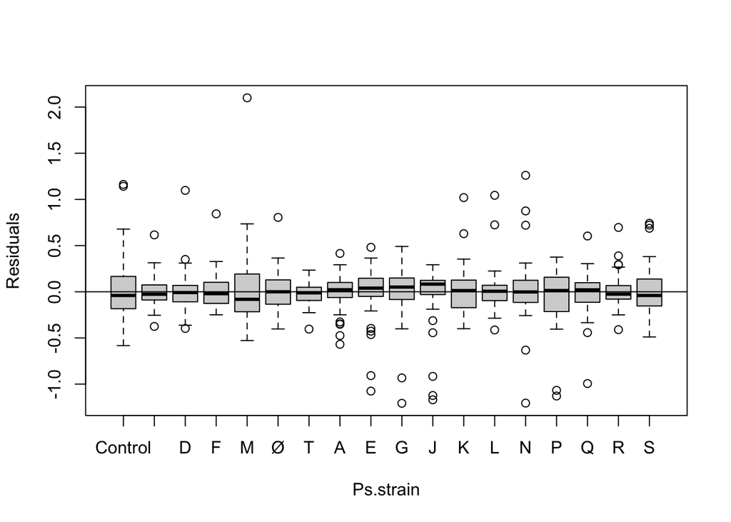

```r
plot(assay3$Ps.strain, resid(M2), xlab = "Ps.strain", ylab = "Residuals")
abline(0, 0)
```

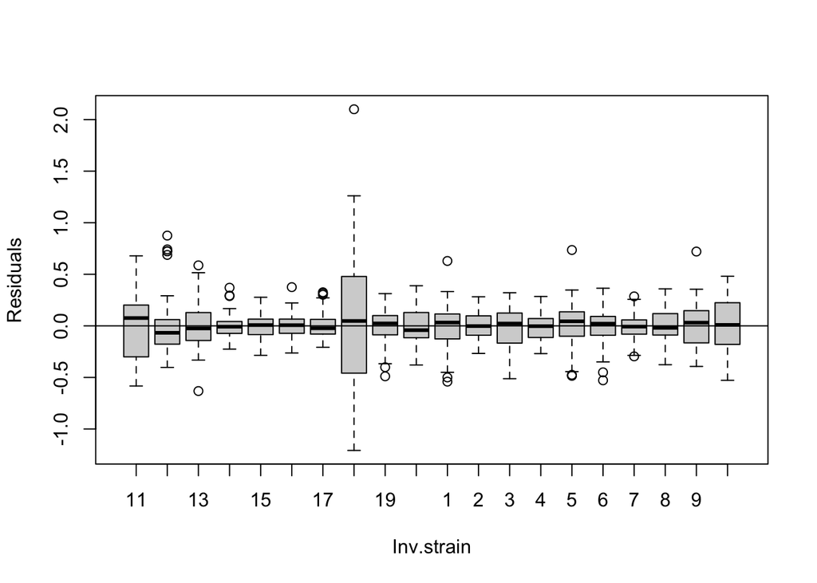

```r
plot(assay3$Inv.strain, resid(M2), xlab = "Inv.strain", ylab = "Residuals")
abline(0, 0)
```

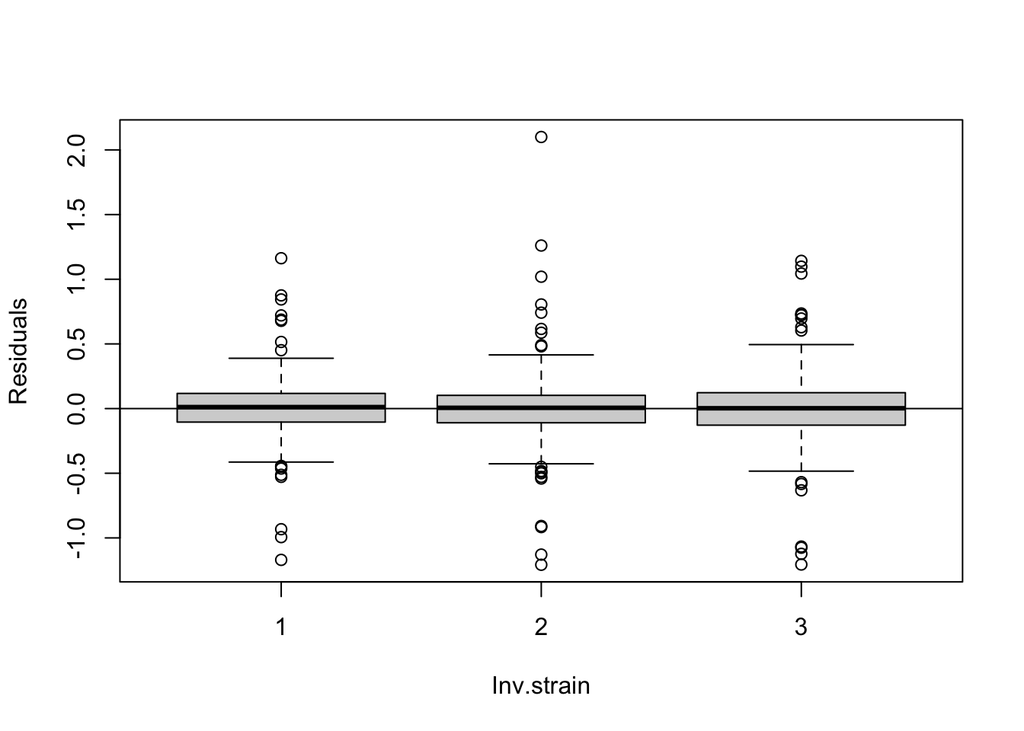

```r
plot(assay3$Plate, resid(M2), xlab = "Inv.strain", ylab = "Residuals")
abline(0, 0)
```

The correlated residuals have gone away, as expected, although Inv.strain 18 has greater variance than the other strains.

### Effect of Ps1 vs Ps2

From the Andersen et al.’s (2013) results, we hypothesised that Ps2 would be a stronger growth suppressor than is Ps1.

Remove the Control level and test again for a significant main effect of Ps.genotype (Ps1 vs Ps2).

```r
assay4 <- assay3 %>% filter(Ps.genotype != "Control")
assay4$Ps.genotype <- fct_drop(assay4$Ps.genotype)

M5 <- lmer(Invasion.score ~ Invader + Ps.genotype + (1 | Ps.strain / Plate) + (1 | Inv.strain), data = assay4, REML = FALSE)
M6 <- lmer(Invasion.score ~ Invader + (1 | Ps.strain) + (1 | Inv.strain / Plate), data = assay4, REML = FALSE)
```

```
## boundary (singular) fit: see ?isSingular
```

```r
anova(M5, M6)
```

```
## Data: assay4
## Models:
## M6: Invasion.score ~ Invader + (1 | Ps.strain) + (1 | Inv.strain/Plate)
## M5: Invasion.score ~ Invader + Ps.genotype + (1 | Ps.strain/Plate) +
## M5:     (1 | Inv.strain)
##    npar    AIC    BIC  logLik deviance  Chisq Df Pr(>Chisq)
## M6    6 262.30 291.22 -125.15   250.30
## M5    7 239.75 273.49 -112.88   225.75 24.547  1  7.252e-07 ***
## ---
## Signif. codes:  0 '***' 0.001 '**' 0.01 '*' 0.05 '.' 0.1 ' ' 1
```

Ps.genoptype is highly significant (p = 7.252e-07): growth is different between the Ps1 and Ps2-infused media

Now estimate parameter value

```r
M7 <- lmer(Invasion.score ~ Invader + Ps.genotype + (1 | Ps.strain / Plate) + (1 | Inv.strain), data = assay4, REML = TRUE)
summary(M7)
```

```
## Linear mixed model fit by REML ['lmerMod']
## Formula: Invasion.score ~ Invader + Ps.genotype + (1 | Ps.strain/Plate) +
##     (1 | Inv.strain)
##    Data: assay4
##
## REML criterion at convergence: 235.3
##
## Scaled residuals:
##     Min      1Q  Median      3Q     Max
## -4.6084 -0.4300  0.0246  0.4237  8.4790
##
## Random effects:
##  Groups          Name        Variance Std.Dev.
##  Plate:Ps.strain (Intercept) 0.004776 0.06911
##  Inv.strain      (Intercept) 0.101101 0.31796
##  Ps.strain       (Intercept) 0.007725 0.08789
##  Residual                    0.063913 0.25281
## Number of obs: 915, groups:  Plate:Ps.strain, 50; Inv.strain, 20; Ps.strain, 17
##
## Fixed effects:
##                     Estimate Std. Error t value
## (Intercept)          0.80151    0.10944   7.324
## InvaderStreptomyces  0.05267    0.14322   0.368
## Ps.genotypePs2      -0.16489    0.05235  -3.150
##
## Correlation of Fixed Effects:
##             (Intr) InvdrS
## InvdrStrptm -0.655
## Ps.gntypPs2 -0.312  0.002
```

Growth rate is lower on Ps2 (-0.16489)